HsHsieh · Cardiology · Hsinchu

Talk / 2026 — 05 — 13 · v2

# AI 數位科技 應用於醫學教育

AAI & Medical Education

Lecture · v2 · 38 slides · 9 sections

# From *USMLE* 86% to **redesigning** medical learning.

**Speaker**

謝慕揚 MD, PhD, FESC

**Sources**

[BEME 84](https://doi.org/10.1080/0142159X.2024.2314198) · [Macy](https://doi.org/10.1097/ACM.0000000000006107) · AAMC · WHO · AMEE

**Compiled**

2026 / 05 / 13 · v2

00|Outline

AI & Medical Education · Hsinchu 2026

大綱 · Roadmap · v2

# 九個篇章。 從 考試表現 到 落地實作。

由 BEME Guide 84、Macy 報告、AAMC v2.0 與六部 AMEE Guides 串連的最新證據;v2 新增第九章 — 講者自己在新竹台大已經落地的六個 AI 教學工作流程。

1. 為什麼現在要談 AI 與醫學教育？
2. LLM 在醫學考試的驚人表現
3. AI 作為教學工具:虛擬病人與導學
4. AI 在評量與回饋
5. VR / AR / XR 沉浸式學習
6. 倫理、學術誠信與政策
7. 國際指引:AAMC、WHO、AMEE
8. 台灣現況與未來展望
9. **實作範例**:讀書會、NEJM、Email、問診訓練、行政、手機 App

**AI** Artificial Intelligence 人工智慧·**LLM** Large Language Model 大型語言模型·**VR/AR/XR** Virtual / Augmented / Extended Reality 虛擬‧擴增‧延展實境·**AAMC** Association of American Medical Colleges·**WHO** World Health Organization·**AMEE** Association for Medical Education in Europe·**BEME** Best Evidence Medical Education

01

Section · 第一部分

# AI 爆發的時代。

— The age of generative AI in medicine.

Why now?2022 → 2026

**AI** Artificial Intelligence 人工智慧

01.1|The age of generative AI

2022 → 2026

為什麼現在要談 AI?

# 三年內, AI 從 玩具 變成 考試冠軍。

2022 年底 ChatGPT 發布後,LLM 的醫學考試表現以季為單位改寫紀錄。國際指引從零到六部 AMEE Guides,只用了三年。

2022.11**ChatGPT 發布** · 公眾首次接觸 LLM

2023.03GPT-4 通過 USMLE (~86%)

2023.07Med-PaLM 2 達 86.5% *(Nature)*

2024.01WHO AI Ethics 指引發布

2024.03BEME Guide No. 84 (278 篇文獻)

2025.01AAMC AI Principles v1.0

2025.07**AAMC AI Principles v2.0**

2025.08MEDINFO 2025 台北

2025.09**Macy Foundation 報告**

[<sup>1</sup>Lee NEJM 2023](https://doi.org/10.1056/NEJMsr2214184) [<sup>2</sup>Singhal Nature 2023](https://doi.org/10.1038/s41586-023-06291-2) [<sup>3</sup>Gordon BEME 84 2024](https://doi.org/10.1080/0142159X.2024.2314198) [<sup>4</sup>Boscardin Macy 2025](https://doi.org/10.1097/ACM.0000000000006107)

**AI** Artificial Intelligence·**LLM** Large Language Model·**GPT** Generative Pre-trained Transformer·**USMLE** United States Medical Licensing Examination 美國醫師執照考試·**WHO** World Health Organization·**BEME** Best Evidence Medical Education·**AAMC** Association of American Medical Colleges·**AMEE** Association for Medical Education in Europe·**MEDINFO** World Congress on Medical & Health Informatics

01.2|Application landscape

教學 · 評量 · 臨床技能 · 行政

AI 在醫學教育的應用地圖

# 四個分支,十二項應用。

教學Teaching

- LLM 個人化導學
- 虛擬病人 (Virtual Patients)
- 適性學習平台

評量Assessment

- 自動化評分
- 隱匿式評量 (Stealth Assessment)
- 學習軌跡預測

臨床技能Clinical Skills

- VR / AR 手術訓練
- AI-ECG 判讀
- 遊戲化學習

行政Admin

- 入學審查 NLP
- 課程優化
- 學分管理

**AI** Artificial Intelligence·**LLM** Large Language Model·**VR/AR** Virtual / Augmented Reality 虛擬實境 / 擴增實境·**ECG** Electrocardiogram 心電圖·**NLP** Natural Language Processing 自然語言處理

02

Section · 第二部分

# LLM 的醫學考試表現。

— Where machines now sit on the exam curve.

From 60 % to 95 %2023 → 2025

**LLM** Large Language Model·**USMLE** United States Medical Licensing Examination 美國醫師執照考試

02.1|USMLE benchmark

Network meta-analysis · 120 evaluations

LLM 在 USMLE 的進化

# 三年內,從 及格邊緣 到 95 %。

120 evaluations · 16 models · 9 languages — 13/16 已超過 60 % 及格線。

ChatGPT (3.5)2023

60 %

GPT-42023

86 %

Med-PaLM 2Nature 2023

86.5 %

GPT-4o2024

89 %

GPT-o12025

95.4 %

**Pearl** · 三年內接近滿分,但這不代表臨床能力。

Fig · Singhal 2023

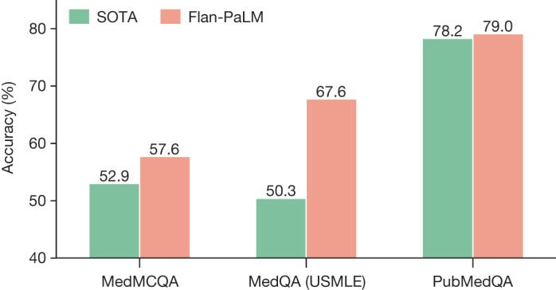

Med-PaLM / Flan-PaLM 540B 在 MedQA、MedMCQA、PubMedQA 三大資料集首度全面超越前任 SOTA。[Nature 2023](https://doi.org/10.1038/s41586-023-06291-2)

[<sup>1</sup>Lee NEJM 2023](https://doi.org/10.1056/NEJMsr2214184) [<sup>2</sup>Singhal Nature 2023](https://doi.org/10.1038/s41586-023-06291-2) [<sup>3</sup>Kasagga Cureus 2025](https://doi.org/10.7759/cureus.94300)

**LLM** Large Language Model·**USMLE** United States Medical Licensing Examination·**GPT** Generative Pre-trained Transformer·**SOTA** State-Of-The-Art 當時最佳·**MedQA / MedMCQA / PubMedQA** 三大醫學問答評測資料集

02.2|The other 44 %

Wei 2024 SR · Kasagga 2025 NMA

但 LLM 不是萬能的

# 考試 95 %, 臨床問題 56 %。

56 % Overall accuracy · ChatGPT 醫學回應 95 % CI: 51–60 % · n = 60 studies

| 情境 | LLM 表現 |
| --- | --- |
| 結構化考試 (MCQ) | **優秀 86–95 %** |
| 開放式臨床問題 | **中等 ~56 %** |
| 軟技能 (溝通、倫理) | **GPT-4: 90 %** |
| 即時臨床決策 | **仍不可靠** |

**Pearl** · LLM 適合作為學習工具,不適合作為臨床決策的唯一依據。

Fig · Kasagga 2025

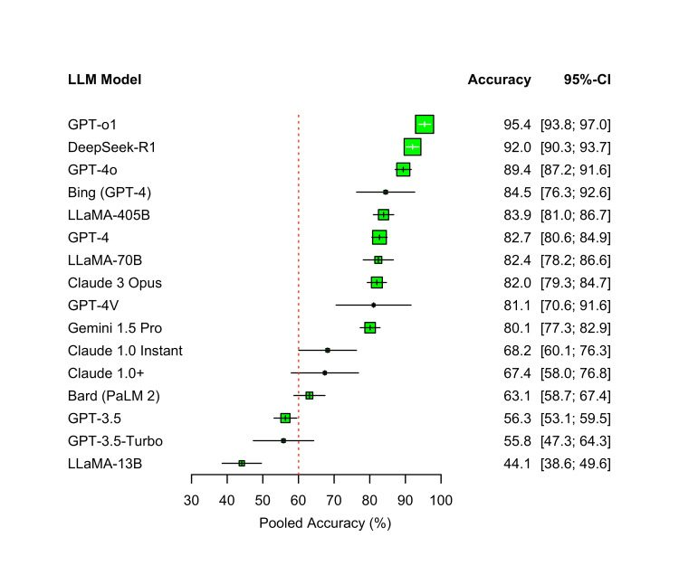

120 項評估、10 種考試系統下各 LLM 之合併準確率森林圖,以 60 % 為通過閾值。[Cureus 2025](https://doi.org/10.7759/cureus.94300)

[<sup>1</sup>Wei JBI 2024](https://doi.org/10.1016/j.jbi.2024.104620) [<sup>2</sup>Kasagga Cureus 2025](https://doi.org/10.7759/cureus.94300)

**LLM** Large Language Model·**MCQ** Multiple Choice Question 選擇題·**GPT** Generative Pre-trained Transformer·**CI** Confidence Interval 信賴區間·**SR** Systematic Review 系統綜述·**NMA** Network Meta-Analysis 網絡統合分析

03

Section · 第三部分

# AI 教學工具。

— Virtual patients, tutoring, multi-platform comparison.

Tutoring & simulation2023 — 2025

**AI** Artificial Intelligence·**LLM** Large Language Model

03.1|Virtual patients

Zeng 2025 · Holderried 2024

AI 虛擬病人 · 爆發成長

# 問診訓練,幾乎完美 的臨床合理性。

Fig · Zeng 2025

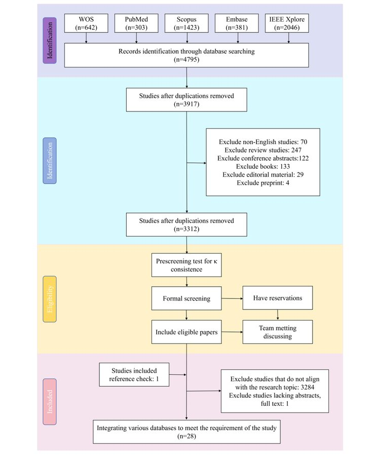

JMIR scoping review · PRISMA 流程,4,795 → 28 篇納入。[JMIR 2025](https://doi.org/10.2196/79091)

Scoping review

### Zeng 2025 — 28 studies

92.9 % 發表於近 2 年

應用:問診訓練、臨床推理、病史詢問、文化敏感度。

Holderried 2024

### GPT-4 模擬病人

> 99 %Medically plausible

κ 0.832Almost perfect

106 conversations · 1,894 Q&A pairs

Fig · Holderried 2024

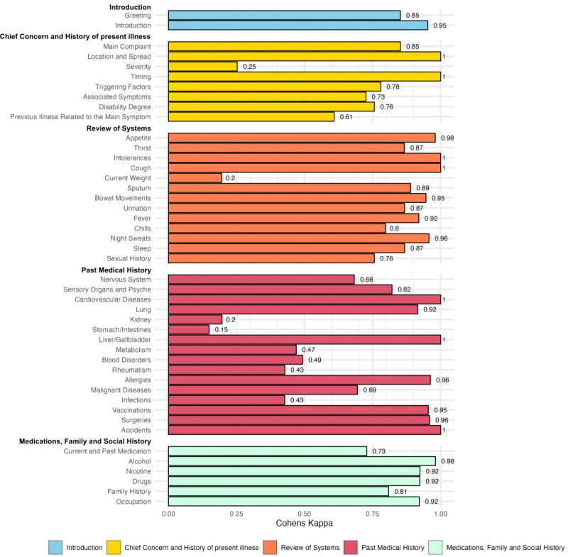

**Pearl** · AI 虛擬病人已可達「幾乎完美」的臨床合理性 — 進入課程已不是技術問題,而是設計問題。

[<sup>1</sup>Zeng JMIR 2025](https://doi.org/10.2196/79091) [<sup>2</sup>Holderried JMIR Med Educ 2024](https://pmc.ncbi.nlm.nih.gov/articles/PMC11364946/)

**LLM** Large Language Model·**GPT** Generative Pre-trained Transformer·**κ** Cohen's kappa 一致性係數·**PRISMA** Preferred Reporting Items for Systematic Reviews 系統綜述報告準則·**SP** Standardized Patient 標準化病人

03.2|GAI vs traditional teaching

Li 2025 · Meta-analysis · 11 RCTs · n = 786

GAI 教學 vs 傳統

# 知識相當, 實作技能 GAI 較好。

81.8 % 使用 ChatGPT · 72.7 % 來自亞洲機構。SMD 0.63 在實作技能達顯著差異。

Fig · Li 2025

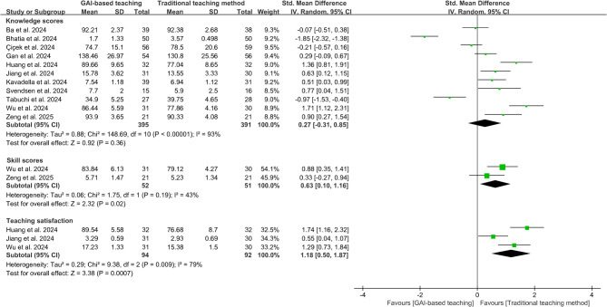

BMC 統合分析森林圖 · 生成式 AI 在實作技能優於傳統 (SMD 0.63);知識面則無顯著差異。[BMC Med Educ 2025](https://doi.org/10.1186/s12909-025-07750-2)

| 結果 | SMD | P |
| --- | --- | --- |
| 知識獲得 | 0.27 | 0.36 |
| **實作技能** | **0.63** | **0.02** |
| 學生滿意度 | 較高 | — |

**結論** · GAI 在 *動手做* 與滿意度上有顯著優勢。

[<sup>1</sup>Li BMC Med Educ 2025](https://doi.org/10.1186/s12909-025-07750-2)

**GAI / GenAI** Generative AI 生成式人工智慧·**RCT** Randomized Controlled Trial 隨機對照試驗·**SMD** Standardized Mean Difference 標準化平均差·**P** P value 顯著性檢定 P 值

03.3|Multi-platform LLM teaching

Mavrych 2025 · Anatomy & Neuroscience

多平台 LLM 教學比較

# 四個 LLM,全部超越學生平均。

ChatGPT

### 解剖 優 · 神經 優

最廣泛使用。寫作流暢、引用整合度高。學生熟悉度最高。

Claude

### 解剖 優 · 神經 優

長文脈絡能力強 (200k+ tokens)。Journal reading 與綜合分析特別出色。

Copilot

### 解剖 中 · 神經 中

搜尋整合佳。即時擷取最新文獻來源,但深度回答較弱。

Gemini

### 解剖 優 · 神經 良

多模態能力強 — 影像、ECG、影片皆可輸入。Google Scholar 整合佳。

— 不同模型各有擅長領域,建議「主力 + 對照」雙工具策略。

**LLM** Large Language Model·**ChatGPT / Claude / Copilot / Gemini** 主流大型語言模型平台·**ECG** Electrocardiogram 心電圖

04

Section · 第四部分

# AI 評量與回饋。

— Auto-grading, stealth assessment, feedback loops.

AMEE Guide 178The future of CBME

**AI** Artificial Intelligence·**AMEE** Association for Medical Education in Europe·**CBME** Competency-Based Medical Education 能力導向醫學教育

04.1|Four applications

Simulation · Surgery · Stealth · Feedback

AI 在評量的四大應用

# 從自動評分到隱匿式評估。

01 · Auto-grading

### 自動化模擬評量

Deep learning model — Anaphylaxis simulation pass/fail 自動判定。

71 %Accuracy

0.68F1-score

02 · Surgical skill

### 手術技能自動評量

CNN / RNN 用於 robotic surgery assessment — 客觀、即時的技術評分。

適用 da Vinci、模擬器 OSCE 流程。

03 · Stealth assessment

### 隱匿式評量

嵌入學習活動中,**不知不覺地**評估能力 — 學生無考試焦慮。

CBME (Competency-Based Medical Education) 的未來關鍵技術。

04 · Soft-skills feedback

### 溝通技巧 AI 回饋

自動偵測 eye contact、body language,生成 actionable feedback。

即時、可重複,降低 SP cost。

**AI** Artificial Intelligence·**CNN** Convolutional Neural Network 卷積神經網路·**RNN** Recurrent Neural Network 遞迴神經網路·**F1** F1-score (精確率與召回率調和平均)·**CBME** Competency-Based Medical Education 能力導向醫學教育·**OSCE** Objective Structured Clinical Examination 客觀結構化臨床考試·**SP** Standardized Patient 標準化病人

04.2|AMEE Guide No. 178

2025 · 目前最全面的 AI 評量指引

AMEE Guide No. 178

# AI 評量 指引 — 2025。

從文字評分到 AI as Tutor / Learner,涵蓋教師與學生的能力建構與倫理框架。

**Pearl** · 目前最全面的 AI 在 medical assessment 指引文件。

| 面向 | 內容 |
| --- | --- |
| **文字評量** | 自動化 written response 評分 |
| **影像判讀** | AI feedback on interpretation |
| **AI as Tutor** | AI 扮演教師角色 |
| **AI as Learner** | AI 模擬學生理解 |
| **所需能力** | 教師 + 學生的 AI competencies |
| **倫理議題** | Bias, fairness, transparency |

[<sup>1</sup>Masters AMEE 178 · Med Teach 2025](https://doi.org/10.1080/0142159X.2024.2445037)

**AI** Artificial Intelligence·**AMEE** Association for Medical Education in Europe·**Tutor / Learner** 教師 / 學習者 (AI 扮演的角色)

05

Section · 第五部分

# VR / AR / XR 沉浸式學習。

— When the simulator becomes the classroom.

Sadek 2023 · Toni 202453 studies · 20 countries

**VR** Virtual Reality 虛擬實境·**AR** Augmented Reality 擴增實境·**XR** Extended Reality 延展實境·**MR** Mixed Reality 混合實境

05.1|Extended Reality in MedEd

VR · AR · MR · Gamification

延展實境在醫學教育

# COVID-19 加速採用, 外科 trainee 接受度高。

VR

### 手術模擬 · 解剖

沉浸式、可重複。風險為零,反覆練習。

FundamentalVR · Osso VR

AR

### 床邊教學 · 超音波

真實環境疊加,臨床情境結合。

HoloLens 引導 POCUS

Mixed Reality

### 複雜手術規劃

結合虛實 — 影像與實體疊合。

Cardiac & neuro pre-op planning

**Sadek 2023** · VR / AR *維持或提升* 了疫情期間教育品質。

**Gamification** · 53 studies / 20 countries — 提升 clinical reasoning engagement。

**VR** Virtual Reality 虛擬實境·**AR** Augmented Reality 擴增實境·**MR** Mixed Reality 混合實境·**XR** Extended Reality 延展實境·**POCUS** Point-of-Care Ultrasound 即時超音波·**HoloLens** Microsoft 混合實境頭戴裝置

06

Section · 第六部分

# 倫理與政策。

— Integrity, bias, the missing 67.7 %.

Rush 2026 · 146 schoolsAMEE 158 · AMEE 192

**AI** Artificial Intelligence·**AMEE** Association for Medical Education in Europe

06.1|Academic integrity

Rush 2026 · 146 U.S. medical schools

學術誠信的新挑戰

# 多數政策 只聚焦 禁止作弊。

GenAI 可生成難以偵測的作業;AI detector 偽陽/陰性率仍高。

32.3 % Framework subthemes covered (avg.) 146 醫學院政策審查

| 最常涵蓋 | % |
| --- | --- |
| Academic Honesty | **81.5** |
| Appropriate Use | ~70 |

| 最少涵蓋 | % |
| --- | --- |
| Technical Infrastructure | **6.2** |
| Environmental Stewardship | **1.4** |

**缺口** · 多數政策缺乏整體 AI 策略。

[<sup>1</sup>Rush Med Teach 2026](https://doi.org/10.1080/0142159X.2025.2564869)

**AI** Artificial Intelligence·**GenAI** Generative AI 生成式人工智慧·**Framework subtheme** 政策框架次主題·**Detector** AI 內容偵測器

06.2|AMEE Guide 158

Masters K. 2023 · 倫理八大面向

AMEE 倫理指引重點

# AMEE Guide 158 · 八大面向。

01

### Data gathering

資料收集倫理 — 來源、同意、用途。

02

### Privacy

隱私保護 — 個資、再識別風險。

03

### Consent

知情同意 — 學生、病人雙向。

04

### Data ownership

資料所有權 — 學校、平台、學習者。

05

### Security

資安 — 防滲漏、滲透測試。

06

### Bias

AI 偏差 — 性別、種族、語言。

07

### Transparency

透明度 — 模型、資料、決策過程。

08

### Responsibility

責任歸屬 — 教師、機構、開發者。

+ **AMEE Guide 192** · 學術出版 AI 揭露框架 — Authorship, verification, plagiarism, bias.

[<sup>1</sup>Masters AMEE 158 · Med Teach 2023](https://doi.org/10.1080/0142159X.2023.2186203)

**AI** Artificial Intelligence·**AMEE** Association for Medical Education in Europe·**Bias** 模型偏差·**Authorship** 著作權歸屬

07

Section · 第七部分

# 國際指引。

— AAMC · WHO · UNESCO · AMEE.

2024 — 2025Six AMEE Guides

**AAMC** Association of American Medical Colleges·**WHO** World Health Organization·**UNESCO** United Nations Educational, Scientific and Cultural Organization·**AMEE** Association for Medical Education in Europe

07.1|Three international voices

AAMC · WHO · UNESCO

三大國際組織的 AI 教育立場

# 不應以 AI 取代臨床判斷。

AAMC · 2025

### Principles v2.0

七大原則 + AI Competencies。與 AMEE, IAMSE, APMEN, AAHCI 國際合作。

涵蓋 AI 整合、learner support、教育流程。

WHO · 2024

### AI Ethics for Health

40+ 建議 — 不應以 AI 取代臨床判斷。從 AI 開發早期即納入 stakeholder engagement。

Geneva: WHO; 2024.

UNESCO · 2024

### AI Competency Frameworks

教師 + 學生 AI 能力框架 — 全球教育系統共通語言。

Teacher & Student frameworks · 2024.

[<sup>1</sup>WHO AI Ethics 2024](https://www.who.int/publications/i/item/9789240084759) [<sup>2</sup>AAMC Principles v2.0 · 2025](https://www.aamc.org/about-us/mission-areas/medical-education/principles-ai-use)

**AAMC** Association of American Medical Colleges·**WHO** World Health Organization·**UNESCO** United Nations Educational, Scientific and Cultural Organization·**IAMSE** Int'l Association of Medical Science Educators·**APMEN** Asia Pacific Medical Education Network·**AAHCI** Assoc. of Academic Health Centers International

07.2|AMEE Guides 2023–2025

六部指引,三年成書

AMEE Guides 總覽

# 六份指引 — AI 在醫學教育最完整的指引體系。

從研究方法、倫理、評量、AGI 準備、共創到學術出版,六個 AMEE Guides 各補一塊拼圖。

| Guide | 主題 | 對象 |
| --- | --- | --- |
| **No. 156** | AI in MedEd Research 基礎 | 研究者 |
| **No. 158** | AI 倫理使用 | 所有教育者 |
| **No. 172** | 為 AGI 做準備 | 機構決策者 |
| **No. 178** | **AI 在 Assessment** | 評量設計者 |
| **No. 190** | AI in Co-Creation | 課程設計者 |
| **No. 192** | 學術出版 AI 揭露 | 研究者 / 作者 |

**AMEE** Association for Medical Education in Europe·**AGI** Artificial General Intelligence 通用人工智慧·**Co-Creation** 共同創作 (師生協作 AI 課程)·**MedEd** Medical Education 醫學教育

08

Section · 第八部分

# 台灣與未來。

— What we have, and what we should do next.

MEDINFO 2025 · 台北AI Taiwan Action Plan 2.0

**AI** Artificial Intelligence·**MEDINFO** World Congress on Medical & Health Informatics 世界醫療資訊大會

08.1|Taiwan today

AI 醫療論文全球第 10

台灣 AI 醫療教育現況

# 論文全球第 10, 政策已就位。

1,331AI 醫療論文 (2024)

72.7 %GAI 教學研究來自亞洲

**挑戰** · LLM 在中文考試表現較低 — 語言仍是非英語區國家的關鍵差距。

| 項目 | 現況 |
| --- | --- |
| AI 醫療論文全球排名 | **第 10 (1,331 篇, 2024)** |
| 國家政策 | AI Taiwan Action Plan 2.0 |
| 國際會議 | **MEDINFO 2025 台北** |
| 學術機構 | 北醫大 AI in Medicine 碩士班 |
| 健保署合作 | Google Health 五年 AI 計畫 |
| 醫院認證 | 多家 HIMSS Stage 7 |

**AI** Artificial Intelligence·**GAI** Generative AI 生成式人工智慧·**LLM** Large Language Model·**HIMSS** Healthcare Information & Management Systems Society·**MEDINFO** World Congress on Medical & Health Informatics

08.2|What you can do today

Five workflows

現在就可以做的事

# 五個 立即可用 的 AI 工作流。

01 · Self-study

### LLM 輔助自學

問答、案例討論。

ChatGPT · Claude

02 · Practice

### AI 產生練習題

Formative assessment 自動產出。

GPT-4 · Claude

03 · Simulate

### AI 虛擬病人

History-taking 訓練。

GPT-4 role-play

04 · Read

### AI 文獻整理

Journal reading、摘要、綜整。

Claude · Perplexity

05 · Teach

### AI 簡報製作

教學投影片自動排版。

Marp · Claude · 本投影片

**Pearl** · 你現在看到的這份投影片,就是用 *Claude + HTML* 製作的 — 從 Marp 升級到 frontend 用了一個 prompt。

**AI** Artificial Intelligence·**LLM** Large Language Model·**GPT** Generative Pre-trained Transformer·**Formative assessment** 形成性評量 (學習過程中的非總結性測驗)

08.3|Four recommendations

For medical educators · 2026

對教育者的四個建議

# 不要問「要不要用 AI」, 要問 怎麼負責任地用 AI。

01 · Reframe the question

不要問「要不要用 AI」,要問 **怎麼負責任地用 AI**。

02 · Redesign assessment

從 **assessment redesign** 開始 — AI 能輕易完成的作業,需要重新設計。

03 · AI literacy

培養 **AI literacy** — 不只使用 AI,更要批判性地評估 AI 輸出。

04 · Faculty first

教師自己先學會用 AI — **faculty development** 是成功的關鍵。

**AI** Artificial Intelligence·**AI literacy** AI 素養·**Faculty development** 師資培育·**Assessment redesign** 評量重新設計

Part nine of nine · v2從理論到工作流

09

Section · 第九部分 · v2 新增

# 從理論到實作。 六個我已經落地的 AI 工作流。

— Six AI workflows already in daily use at NTUH Hsinchu Cardiology.

讀書會 · NEJM · Email · 問診 · 行政 · Mobile AppDrake · Hsinchu 2026

**Workflow** 工作流程·**LLM** Large Language Model·**Repo** Repository 程式碼倉·**CDN** Content Delivery Network

09.1|Implementation map · 六大場景

All shipped · 全部已上線

六個實作場景 · Six live workflows

# 不是 demo,是 每週都在跑的工作流。

9.2 · Book club

### 讀書會工作流

8 部教科書同步在跑;每週由 Reading Plan → Progress .md → HTML draft → Gmail 草稿,寄給跨職類讀者。

9.3 · NEJM

### NEJM Case 雙語講義

把 NEJM PDF 丟進資料夾,Claude skill 自動產 LaTeX → xelatex → 雙語講義 + 10 題自測。已累積 50+ 案例。

9.4 · Email

### Gmail HTML 教學郵件

8 種主題色票、7 區塊版型、零記憶 PMID,直接以 inline CSS 出 Gmail 草稿,Drake 審完即寄。

9.5 · Sim patient

### 病史問診 AI Simulator

兩條路:institutional SP 中心,或讓 Claude 扮演標準化病人;對話結束後依 rubric 自動評分回饋。

9.6 · Admin

### 行政管理應用

學生 OSCE 分數彙整、KCCQ / SAQ 計分 QC、月報自動產表;從 CSV 進、PDF/HTML 報表出。

9.7 · Mobile

### HTML 手機教學 App

drake1128/saq-questionnaire GitHub Pages,100+ 單檔 HTML app:衛教、checklist、計算器、SAQ/KCCQ 問卷。

**SP** Standardized Patient 標準化病人·**SAQ** Seattle Angina Questionnaire·**KCCQ** Kansas City Cardiomyopathy Questionnaire·**OSCE** Objective Structured Clinical Examination 客觀結構化臨床測驗·**QC** Quality Control 品管

09.2|Book reading club · 讀書會工作流

8 series · weekly cadence

每週讀書會 · One chapter, one e-mail

# 8 本教科書、 8 種色票、 1 套 PMID 驗證 紀律。

每本書是讀者的「未來手冊章節」。每週由 Claude 把進度筆記翻成 inline-CSS 的 Gmail HTML 草稿,Drake 審完寄給跨職類 BCC 名單(外科、灌注師、血管超音波、藥師、PGY、NP)。

- ECMO ELSO Red Book ‧ CTO (Brilakis) ‧ MitraClip Atlas (Feldman 2013)
- Drugs for the Heart (Opie 8e) ‧ ESC CV Imaging (Zamorano 3e)
- Vascular US (DVT / PAOD 兩階段) ‧ FFR Atlas (Tommaso Gori)

每週 6 步流程 · weekly pipeline

1. **Reading_Plan.md** — 24 週把整本書切章節(例:MitraClip Atlas 2 章/週 × 24 週)
2. **Wk_N_Progress.md** — 本週讀書心得 + 臨床問題
3. **Wk_N_draft.html** — Claude 依進度產草稿(離線預覽)
4. **PubMed 驗證** — 每個 PMID 必須由 search → fetch metadata 確認(零記憶引用)
5. **Gmail Draft** — inline CSS、table-layout:fixed、7 區塊版型
6. **Send** — Drake 預覽後寄給 Reading_Club_Recipients.csv 名單

**Pearl ‧ 黃金規則:**每本書綁一組色票(do not mix);footer 一律署名「**讀書會共筆整理人**」(不可寫成「精選專家」)。

**BCC** Blind Carbon Copy 密件副本·**PMID** PubMed Identifier·**NP** Nurse Practitioner 專科護理師·**PGY** Post-Graduate Year 不分科住院醫師·**SOP** Standard Operating Procedure

09.3|NEJM Case Records · 雙語 LaTeX 講義

50+ cases compiled · 2025 → 2026

NEJM Case Records of MGH

# 把 NEJM PDF 丟進 2026/ 資料夾, Claude 自動產 八節 + 10 題的 LaTeX 講義。

50+

cases / 案例

2

langs / 雙語

10

Q per case

原始素材是 NEJM Case Records 或 Clinical Problem-Solving (CPS) PDF;成品是台大新竹分院住院醫師、PGY、實習醫學生的英文閱讀 + 鑑別診斷訓練教材。

講義八大區塊 · 8 sections

- Case Presentation 病例呈現(HPI / PE / Lab / Imaging)
- **Medical English Writing Analysis** — 4–6 句英文寫作技巧解析
- **Differential Diagnosis** — longtable 跨頁鑑別表(支持 / 不支持 / 建議檢查)
- Workup 進一步檢查 → Final Diagnosis 最終診斷
- Discussion 討論 + Teaching Points 學習要點
- **Self-Test Quiz** — 10 題單選 + 詳解(中英對照)

技術堆疊 · stack

XeLaTeX + xeCJK + longtable + tcolorbox + hyperref ‧ **Drake_preamble.tex** 統一格式 ‧ **.skill** 檔讓 Claude Code 一次到位 ‧ `compile_all.ps1` 批次出 PDF

**NEJM** New England Journal of Medicine·**MGH** Massachusetts General Hospital·**CPS** Clinical Problem-Solving·**HPI** History of Present Illness 現病史·**PE** Physical Examination 身體檢查·**xeCJK** XeLaTeX 中日韓字型套件

09.4|Gmail HTML · 教學郵件流水線

Inline CSS · verified citations

為什麼用 Email 而不只是 PDF?

# 護理長、灌注師、藥師 不會自己去 GitHub 讀 PDF — Email 才會被打開。

Gmail 三條硬規 · hard rules

- **NO <style> block** — Gmail 會整段 strip;CSS 全部 inline 到 element 的 style 屬性
- **table-layout:fixed + colgroup** — 否則 CJK 混 Latin 會排版崩
- **每個 style="..." 都要正確閉合** — 缺一個 " 整個 row 就吞掉

7 區塊版型 · 7 blocks

1. Header banner(主題色)
2. Intro box(臨床情境)
3. 🎯 Take Home — 回家記得三句話
4. Section headers + tables
5. ⚠ Pitfall 黃色 callout
6. 📸 Photo task(讀者貢獻)
7. References + 共筆整理人 footer

零記憶引用 · zero-recall

**規則:**引用任何 PMID / DOI 之前,Claude 必須先用 PubMed 工具實際 search + fetch metadata,從回傳的 record 直接複製 authors / journal / year / volume / pages。

**來由:**2026-04 一封 Grüntzig 史話草稿 7 個 PMID 錯了 5 個 — 後來定為禁忌。

**CSS** Cascading Style Sheets 層疊樣式表·**CJK** Chinese-Japanese-Korean 中日韓字型·**PMID** PubMed Identifier·**DOI** Digital Object Identifier 數位物件辨識碼·**BCC** Blind Carbon Copy

09.5|History-taking training · 病史問診

2 modalities · SP center + Claude

學生病史問診訓練

# 兩條路:SP 中心 一週一場、 或 Claude 扮演病人 隨時可練。

傳統路徑 · Standardized Patient

- **優勢:**真人臨場感 / 非語言訊息 / OSCE 計分可信度高
- **限制:**SP 招募成本、排程僵硬、回饋延遲、難個別化重練
- 適用:期末 OSCE、高風險場景(告知壞消息、知情同意)

新路徑 · Claude as SP

**單一 prompt 就能跑:**

「請扮演一位 65 歲女性,主訴間歇性胸痛 2 週。除非我具體問,否則不要主動透露任何資訊。問完 10 題後,請依下列 rubric 評分我的問診:(1) 完整性 (2) 邏輯順序 (3) 同理 (4) 鑑別診斷導向。」

**成本:**$0 / 隨時可用 / 可重練同一情境直到滿意 / rubric 可以自訂

**Caveat:**Claude 不能取代真人 SP 在 high-stakes assessment 的角色;但作為 **練習場(formative)** 與 **self-debrief 工具**,可以把學生問診時數從每月 1 場拉到每天可練。

**SP** Standardized Patient 標準化病人·**OSCE** Objective Structured Clinical Examination·**Rubric** 評分量表·**Formative** 形成性評量(練習)·**High-stakes** 高風險評量(計分)

09.6|Administrative AI · 行政管理應用

CSV in · report out

把不會被獎勵的雜事自動化

# 分數彙整、月報、問卷 QC、表單回收 — 都可以從 CSV 進 · 報表出。

場景 A · OSCE / 學生分數

把 Google Forms 匯出的 CSV 餵給 Claude,自動產生:每生分數、組距分布、各題答對率、回饋 narrative。一週 200 份不到 5 分鐘。

場景 B · 月報 / 季報

心導管室、CCU、TAVI/TEER 案例月報。從 EMR 匯出的清單 → Claude 整理成表格 + 趨勢圖 + 重要案例註記 → 主管會議直接用。

場景 C · 問卷計分 QC

SAQ / KCCQ 計分容易踩雷(reverse coding、混合量尺、複合分數)。Claude 對照原始發表文獻逐題檢查 — 真實案例:SAQ Q10 方向反轉 bug 是 Claude code review 才抓到。

**PHI 提醒:**任何原始病歷資料進入雲端 LLM 前都要去識別化;高敏感資料建議用本地 LLM(Ollama / vLLM)在院內伺服器跑,或先用 Python 把姓名/病歷號 mask 掉再傳。

**OSCE** Objective Structured Clinical Examination·**EMR** Electronic Medical Record 電子病歷·**CCU** Coronary Care Unit 心臟加護病房·**TAVI** Transcatheter Aortic Valve Implantation·**TEER** Transcatheter Edge-to-Edge Repair·**PHI** Protected Health Information 受保護健康資訊·**QC** Quality Control

09.7|HTML mobile app system · 心血管教學 Hub

drake1128/saq-questionnaire · GitHub Pages

心血管照護教學資源中心

# 100+ 個單檔 HTML App, 每個都能 用手機直接打開。

每隻 app 就是一個 .html 檔(React + Tailwind 走 CDN,不打包、不需後端),push 到 GitHub Pages 60 秒上線,iPhone / Android 連結點開即用,可加到主畫面當 PWA。

100+

single-file apps

7

categories

0

build steps

7 大類別 · categories

- **Orientation** — 2A/2B 病房新進 NP、住院醫師、CCU
- **Calculators** — CV calc、Warfarin dosing、Thrombolytic
- **Checklists** — ProGlide、TEER TEE、VA-ECMO Echo
- **Education** — STEMI ER protocol、Cardiogenic shock、PCI complications
- **Patient education** — TAVI 家屬、CTO 衛教、Carotid stenting
- **Decision aids** — Dementia + PCI、LAAO 神經科決策
- **Questionnaires** — Seattle SAQ、KCCQ(計分已 QC 過)

技術 · stack

React 18 + Babel + Tailwind via CDN ‧ 單檔自含 ‧ mobile-first viewport ‧ Share button ‧ Dark mode ‧ skip-to-content / aria-label / sitemap.xml 已過 WCAG 2.1 AA。

**PWA** Progressive Web App·**CDN** Content Delivery Network·**WCAG** Web Content Accessibility Guidelines 網頁無障礙準則·**NP** Nurse Practitioner·**VA-ECMO** Veno-Arterial Extracorporeal Membrane Oxygenation·**LAAO** Left Atrial Appendage Occlusion 左心耳封閉術

REF|References (1 / 2)

Vancouver style · DOI / PubMed hyperlinked

參考文獻 (1 / 2)

## 所有引用皆附 DOI 連結。

1. Gordon M, et al. BEME Guide No. 84. [*Med Teach.* 2024;46(4):446-470.](https://doi.org/10.1080/0142159X.2024.2314198)
2. Boscardin CK, et al. Macy Foundation Part I. [*Acad Med.* 2025;100(9S):S15-S21.](https://doi.org/10.1097/ACM.0000000000006107)
3. Lee P, et al. GPT-4 for Medicine. [*NEJM.* 2023;388:1233-1239.](https://doi.org/10.1056/NEJMsr2214184)
4. Singhal K, et al. Med-PaLM. [*Nature.* 2023;620:172-180.](https://doi.org/10.1038/s41586-023-06291-2)
5. Kasagga A, et al. LLMs on Medical Exams. [*Cureus.* 2025;17(10):e94300.](https://doi.org/10.7759/cureus.94300)
6. Li J, et al. GAI vs Traditional Teaching. [*BMC Med Educ.* 2025;25:1087.](https://doi.org/10.1186/s12909-025-07750-2)
7. Zeng J, et al. LLM Virtual Patients. [*JMIR.* 2025;27:e79091.](https://doi.org/10.2196/79091)

**DOI** Digital Object Identifier 數位物件辨識碼·**PMID** PubMed Identifier·**BEME** Best Evidence Medical Education·**NEJM** New England Journal of Medicine·**BMC** BioMed Central·**JMIR** Journal of Medical Internet Research

REF|References (2 / 2)

AMEE · Rush · WHO · AAMC · Wei

參考文獻 (2 / 2)

## 指引、政策與系統綜述。

8. Masters K. AMEE Guide No. 158. [*Med Teach.* 2023;45(6):574-584.](https://doi.org/10.1080/0142159X.2023.2186203)
9. Masters K, et al. AMEE Guide No. 178. [*Med Teach.* 2025;47(9):1215-1230.](https://doi.org/10.1080/0142159X.2024.2445037)
10. Rush E, et al. AI Policies Across U.S. Medical Schools. [*Med Teach.* 2026;48(3).](https://doi.org/10.1080/0142159X.2025.2564869)
11. WHO. AI Ethics for Health. [Geneva: WHO; 2024.](https://www.who.int/publications/i/item/9789240084759)
12. AAMC. AI Principles v2.0. [2025.](https://www.aamc.org/about-us/mission-areas/medical-education/principles-ai-use)
13. Wei Q, et al. ChatGPT Medical Responses. [*J Biomed Inform.* 2024;151:104620.](https://doi.org/10.1016/j.jbi.2024.104620)
14. Holderried F, et al. GPT-4 Simulated Patients. [*JMIR Med Educ.* 2024.](https://pmc.ncbi.nlm.nih.gov/articles/PMC11364946/)
15. Mavrych V, et al. Multi-platform LLM teaching. *Med Educ Online.* 2025.

**AMEE** Association for Medical Education in Europe·**WHO** World Health Organization·**AAMC** Association of American Medical Colleges·**JMIR** Journal of Medical Internet Research

AAI & Medical Education

End · Q & A

# 謝謝聆聽。 **Q & A**

HsHsieh · Cardiology

Hsinchu · 2026

# 不要問 「要不要用 AI」, 要問怎麼負責任地用。

**Speaker**

謝慕揚 MD, PhD, FESC

**Disclaimer**

本投影片由 Claude + HTML 協助製作 · 僅供教學參考

**Date**

2026 / 05 / 13 · v2